# PR10_201821479_황혜린

201821479_황혜린

2018년 11월 24일

# 1.ggplot2 기초

## 1-1.ggplot2 plot의 기본성분

Data : 주로 dataframe 형태의 데이터

Aesthetic Mappings : 데이터 축, 색상 및 점의 크기 등으로 매핑하는 방법

Geometric object : 점, 선, 도형과 같은 기하학적 객체

Facetting : 조건부 플롯을 위해 패널을 분할하여 표현하는 방법

Statistical transformation : 구간화, 분위수 평할 등의 통계변환

Scales : 데이터의 스케일을 동적으로 조정하여 어떤 시각적 요소를 사용할 것인가 정의 (e.g., 남성=파랑, 여성=빨강 등으로 지정)

Coordinate system : 좌표계

Position adjustment : 위치의 조정

## 1-2. ggplot2 기본 사용법

mtcars를 활용 : wt(중량), mpg(연비), cyl(실린더의 개수)

```r
library(ggplot2)
head(mtcars)
```

```
##                    mpg cyl disp  hp drat    wt  qsec vs am gear carb
## Mazda RX4         21.0   6  160 110 3.90 2.620 16.46  0  1    4    4
## Mazda RX4 Wag     21.0   6  160 110 3.90 2.875 17.02  0  1    4    4
## Datsun 710        22.8   4  108  93 3.85 2.320 18.61  1  1    4    1
## Hornet 4 Drive    21.4   6  258 110 3.08 3.215 19.44  1  0    3    1
## Hornet Sportabout 18.7   8  360 175 3.15 3.440 17.02  0  0    3    2
## Valiant           18.1   6  225 105 2.76 3.460 20.22  1  0    3    1
```

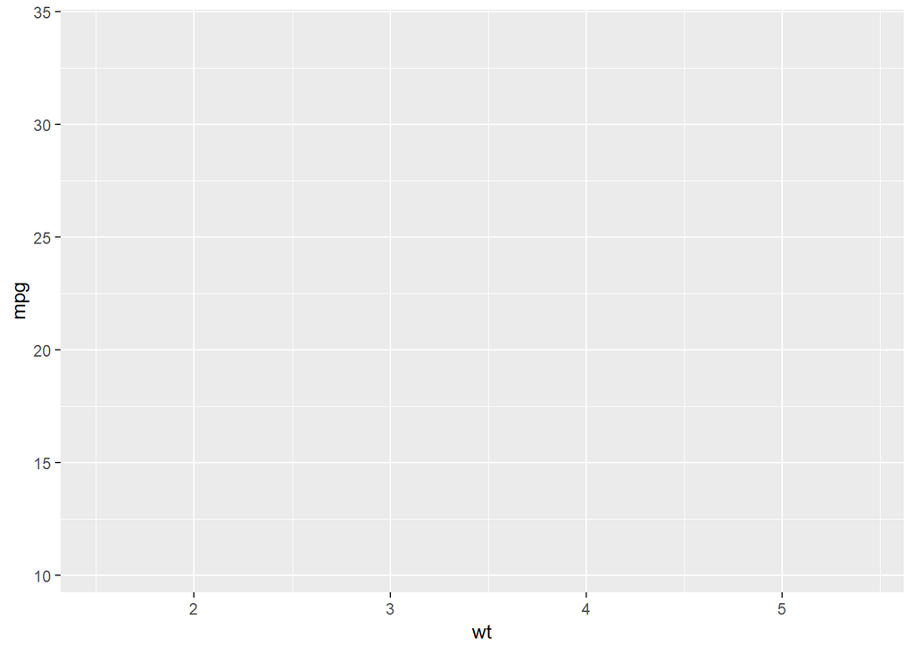

```r
p <-ggplot(data = mtcars, aes(x=wt, y=mpg, colour=cyl)) ; p
```

geom_point()함수를 추가하여 산점도 표현

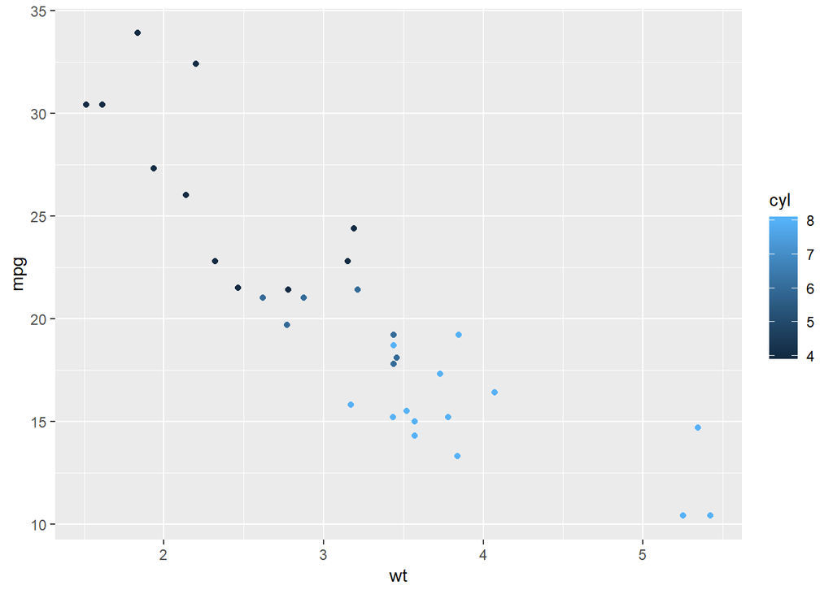

```r
p <- p + geom_point() ; p
```

ggplot 객체의 구조 - summary를 보면 대략적인 그래프를 짐작할 수 있음

-mapping을 보면 x,y축의 데이터와 색상을 결정짓는 변수를 확인가능함 -faceting은 조건부 출력을 의미함. facet_null()은 faceting이 없다는 말

-geom_point는 산점도 그래프라는 의미

-stat_identity는 통계변환이 identity, 즉 변환이 없는 상태의 뎅터라는 것을 의미

-position_identity도 데이터 위치가 어떠한 조정도 없었다는 것을 의미

-na.rm=False는 결측값을 제거하지 않았다는 것을 의미함

```r
class(p)
```

```
## [1] "gg"     "ggplot"
```

```r
attributes(p)
```

```
## $names
## [1] "data"        "layers"      "scales"      "mapping"     "theme"
## [6] "coordinates" "facet"       "plot_env"    "labels"
##
## $class
## [1] "gg"     "ggplot"
```

```r
summary(p)
```

```
## data: mpg, cyl, disp, hp, drat, wt, qsec, vs, am, gear, carb
##   [32x11]
## mapping:  x = ~wt, y = ~mpg, colour = ~cyl
## faceting: <ggproto object: Class FacetNull, Facet, gg>
##     compute_layout: function
##     draw_back: function
##     draw_front: function
##     draw_labels: function
##     draw_panels: function
##     finish_data: function
##     init_scales: function
##     map_data: function
##     params: list
##     setup_data: function
##     setup_params: function
##     shrink: TRUE
##     train_scales: function
##     vars: function
##     super:  <ggproto object: Class FacetNull, Facet, gg>
## -----------------------------------
## geom_point: na.rm = FALSE
## stat_identity: na.rm = FALSE
## position_identity
```

# 1-3. ggplot2로 barplot그리기

-실린더 수에 대한 barplot을 그림

-막대는 기어의 개수에 따라 서로 다른 facet에 출력

-facet이란 독립된 subplot이 그려지는 패널구조를 의미

-결과 값을 보면 3개의 subplot이 있는 것을 확인할 수 있음

-산점도 색상옵션으로 colour인수 사용, barplot은 색상옵션으로 fill인수 사용

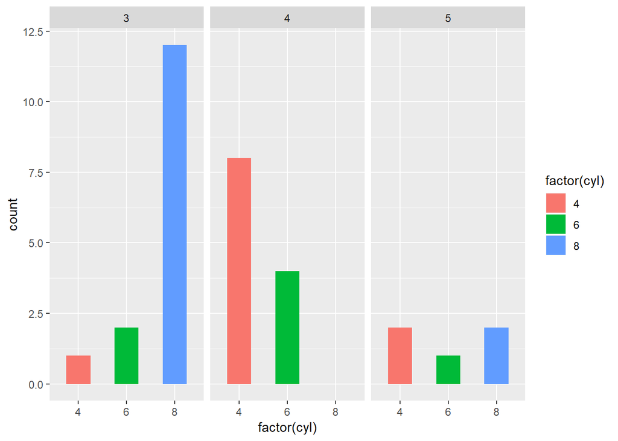

```r
b <- ggplot(data = mtcars, aes(x=factor(cyl), fill=factor(cyl)))
b <- b + geom_bar(width = .5)  #bar의 넓이를 정의
b <- b + facet_grid(.~gear)   #기어 개수에 따른 facet분할
b
```

# 1-4. ggplot Layer

-ggplot을 Layer구조로 정리

-ggplot = layers + scales + coordinate system

-layers = data+mapping + geom + stat + position

-scales와 coordinate system은 그림을 그릴 캔버스의 개념

-layers가 실제로 그리는 그림

-data, mapping, geom 등등으로 하나씩 중첩해 사면서 plot을 그림

-geom의 요소또한 중첩가능

```r
p <- ggplot(mtcars, aes(wt, mpg))
p <- p+geom_point() ; p
```

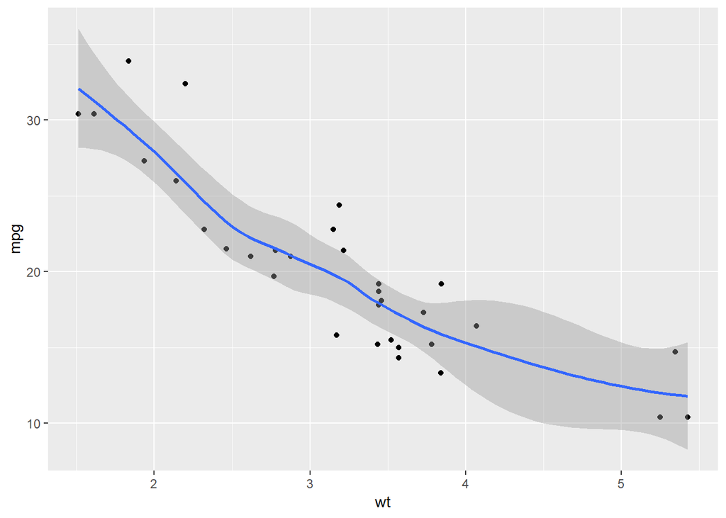

```r
p <- p+geom_smooth(method = "loess")  #라인 그래프 smooth그리기
p
```

```r
summary(p)
```

```
## data: mpg, cyl, disp, hp, drat, wt, qsec, vs, am, gear, carb
##   [32x11]
## mapping:  x = ~wt, y = ~mpg
## faceting: <ggproto object: Class FacetNull, Facet, gg>
##     compute_layout: function
##     draw_back: function
##     draw_front: function
##     draw_labels: function
##     draw_panels: function
##     finish_data: function
##     init_scales: function
##     map_data: function
##     params: list
##     setup_data: function
##     setup_params: function
##     shrink: TRUE
##     train_scales: function
##     vars: function
##     super:  <ggproto object: Class FacetNull, Facet, gg>
## -----------------------------------
## geom_point: na.rm = FALSE
## stat_identity: na.rm = FALSE
## position_identity
##
## geom_smooth: na.rm = FALSE, se = TRUE
## stat_smooth: na.rm = FALSE, se = TRUE, method = loess, formula = y ~ x
## position_identity
```

# 1-5. pplot함수 분류

plot creation : ggplot객체를 생성하는 함수군

geoms : 그래픽의 지오매트릭(기하학적인 형태)을 지정하고 추가하는 함수군

statistics : 데이터를 통계적인 관점으로 변환하는 함수군

scales : 축의 스케일 변환과 라벨, 범례등을 변경하는 함수군

coordinate system : 좌표계를 설정하는 함수군

faceting : 그래픽facet레이아웃을 정의하는 함수군

position adjustments : 지오메트릭의 위치를 지정하는 함수군

anotation : 주석을 표기하는 함수군

fortify : 타 클래스 객체를 데이터 프레임 객테로 변환하는 함수군

themes : 스타일이나 테마를 설정하는 함수군

aesthetics : 데이터를 축, 라벨, 색상 등 기하 구조상 시각적 속성에 매핑하는 함수군

others : 기타함수군

## ggplot 레이어와 함수간 매핑

data : plot creation함수군

mapping : plot creation 함수군, aesthetics 함수군

geom : geoms 함수군

stat : statistics 함수군

position : position adjustments 함수군

# 2. ggplot2 함수군

## 2-1. Plot creating 함수군

-기초 플롯인 ggplot 클래스 객체를 생성

-가장 많이 사용하는 함수는 ggplot()과 qplot()

_ggplot() 함수는 dataframe 객체로 플롯을 그릴 때 사용

-qplot()함수는 각 변수가 독립적인 객체로 존재할 때 사용

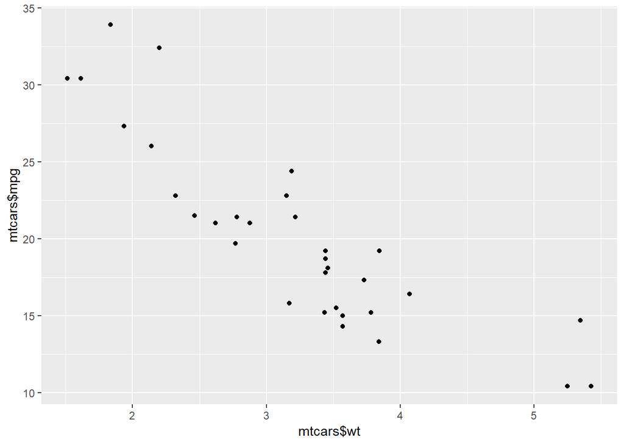

```r
qplot(mtcars$wt, mtcars$mpg)
```

```r
ggplot(mtcars,aes(wt,mpg))+geom_point()
```

-qplot()한수는 geom을 지정하지 않을 경우 point로 적용됨

-ggplot은 모든 그래픽 인수들을 구체적으로 지정해야 함

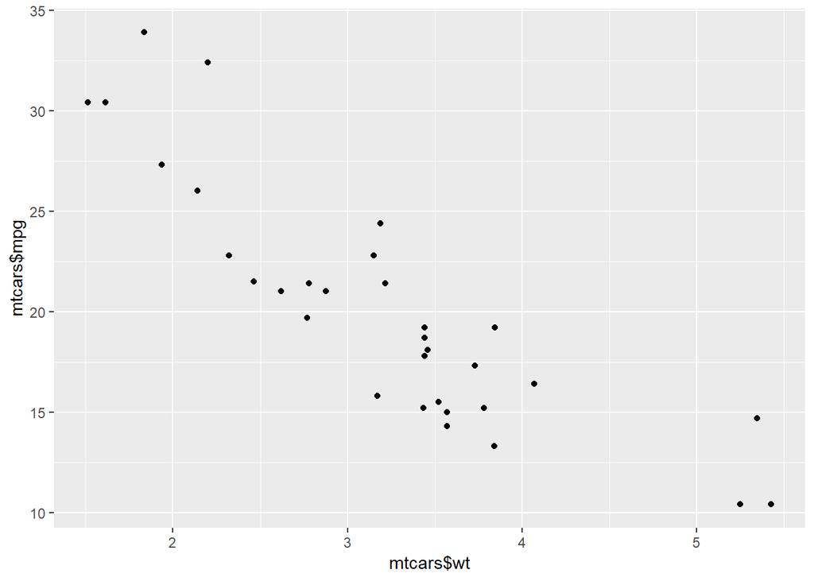

```r
qplot(mtcars$wt, mtcars$mpg, geom = "point")
```

```r
qplot(wt,mpg, data=mtcars, geom =
        "point")  #그래프는 위와 동일함
```

# 2-2. Geoms함수군

- geometric 요소를 지정하기 위한 함수군
- 선, 점 막대, 박스, 파이 등을 생각하면 됨

geom_point() : 산점도

geom_abline() : 추세선 ; 기울기와 절편을 꼭 적어줘야함

geom_bar() : 막대그래프 ; 이산형 변수화 해야함

geom_ribbon() : 영역을 채우는 plot ; geom_area()은 geom_ribbon의 한 형태

geom_boxplot() : 박스플롯

geom_histogram() : 히스토그램

geom_density() : 1차원 데이터에 대한 밀도를 표현하기 위한 함수 ; geom_area() + stat_density()와 동일.

geom_density2d() : 2차원 데이터에 대한 밀도를 표현하는 함수 ; geom_area()+stat_density2d()와 동일. 하지만 복합한 표현을 하려면 stat_density2d()를 직접 사용해야 함

geom_contour() : 등고선을 그리는 용도

geom_text() : plot에 text를 표현하기 위한 함수

geom_map() : 지도를 표현하는 함수

# 2-2-1. geom_point()

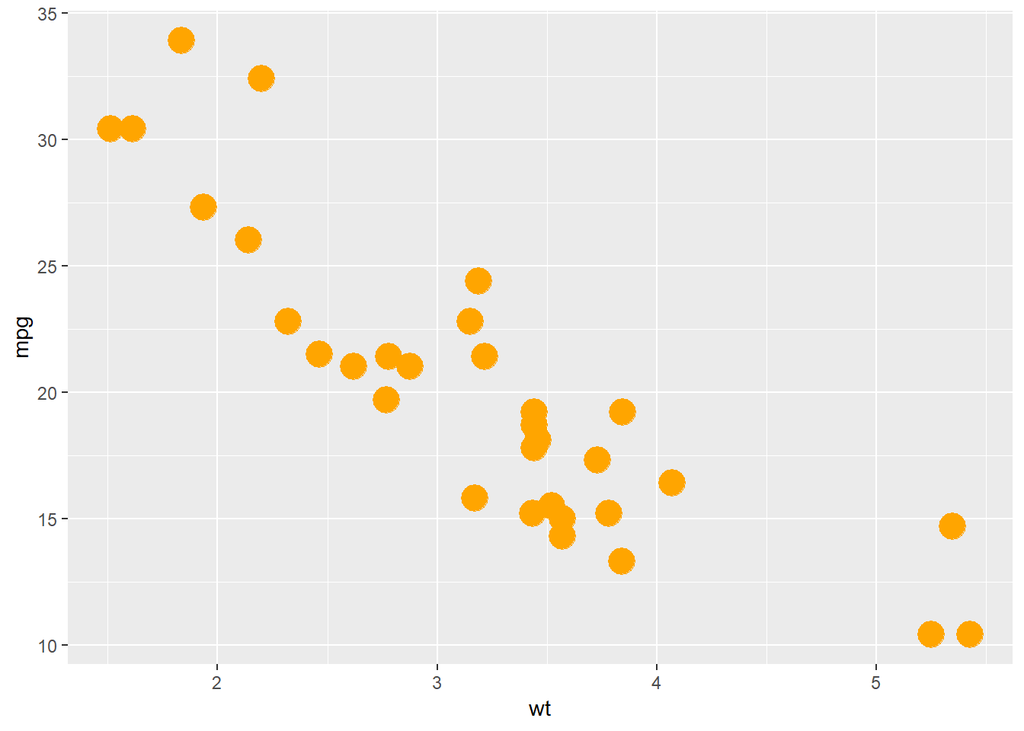

```r
p <- ggplot(data = mtcars, aes(x=wt, y=mpg))
p+geom_point(colour="orange", size=6)
```

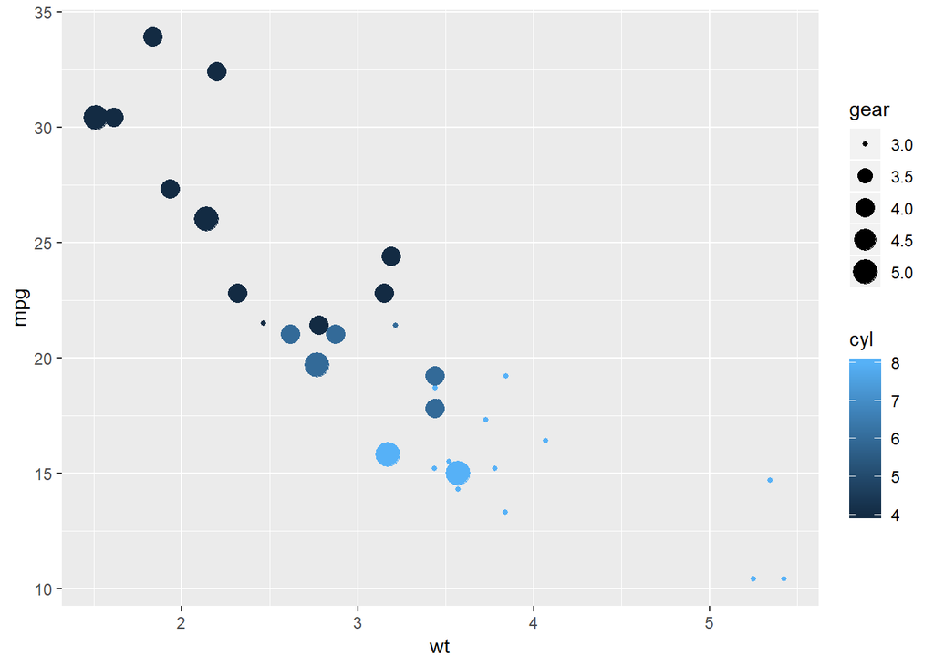

```r
p + geom_point(aes(colour=cyl, size=gear))
```

# 2-2-2. geom_bar()

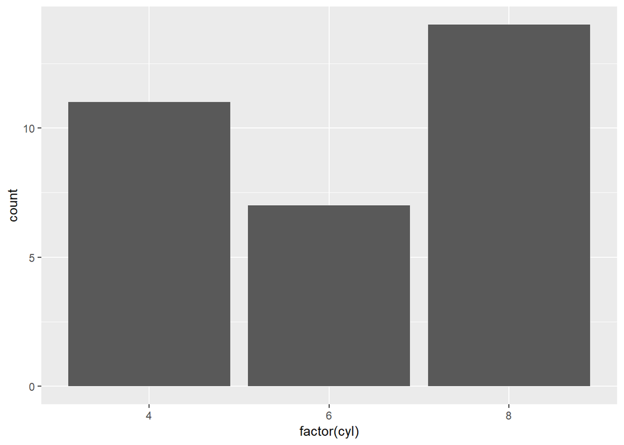

```r
p <- ggplot(mtcars, aes(factor(cyl)))
p + geom_bar()
```

- geom_bar를 aes함수로 꾸미기

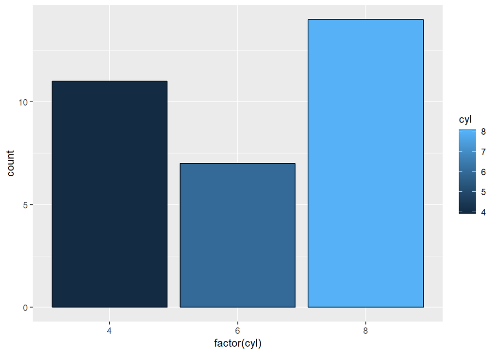

```r
p <- ggplot(mtcars, aes(factor(cyl)))
p + geom_bar(aes(fill=cyl), colour="black")
```

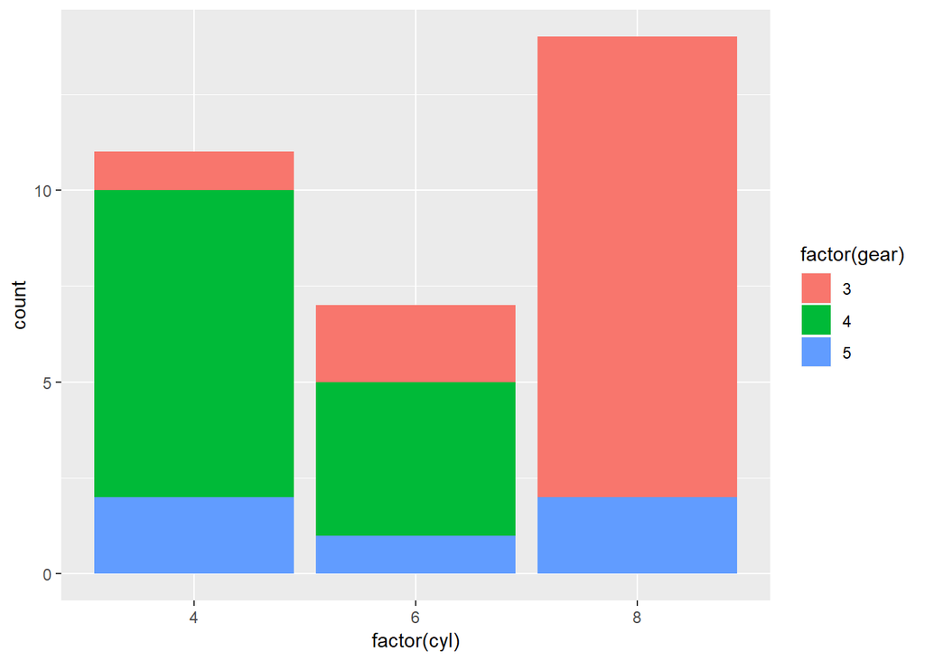

```r
p <- ggplot(mtcars, aes(factor(cyl)))
p + geom_bar(aes(fill=factor(gear)))
```

# 2-2-3. boxplot

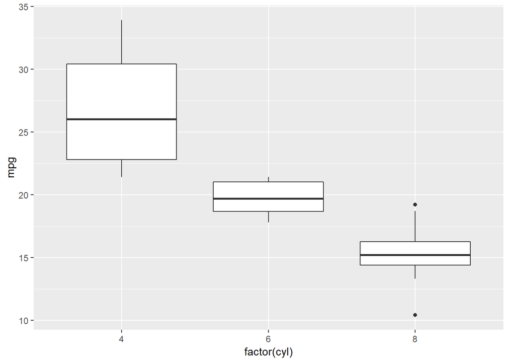

```r
p <- ggplot(mtcars, aes(factor(cyl), mpg))  #기본 박스플랏
p <- p + geom_boxplot() ; p
```

- boxplot을 aes함수로 꾸미기

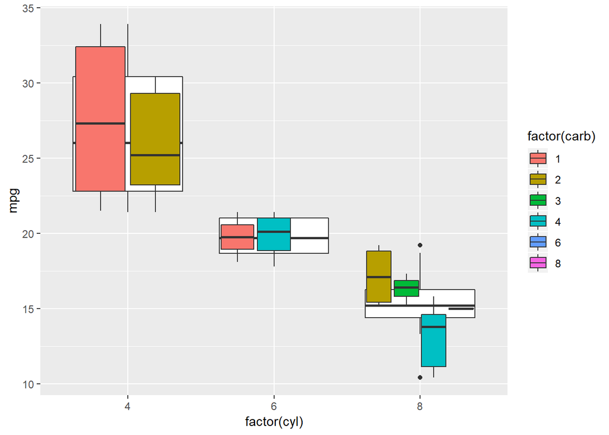

```r
p + geom_boxplot(aes(fill=factor(carb))) #박스 내부를 carb팩터로 구분지어 표현
```

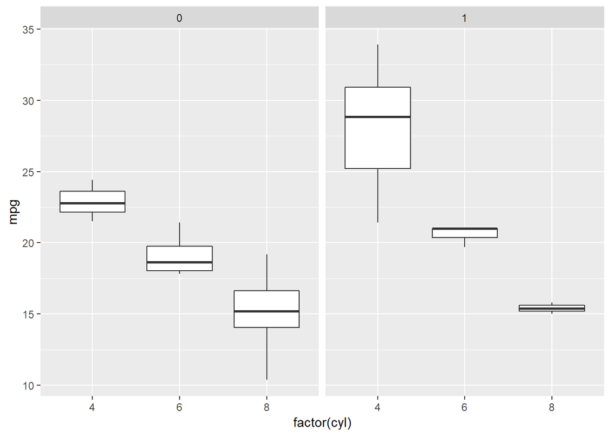

```r
p + facet_grid(~am)  #am을 기준으로 facet분리
```

# 2-2-4. Histogram

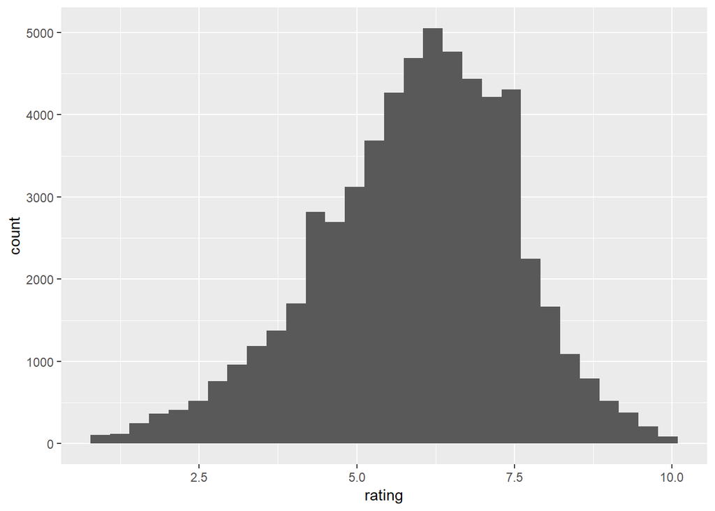

```r
#install.packages("ggplot2movies")
library(ggplot2movies)
p <- ggplot(movies, aes(rating))
p <- p + geom_histogram() ; p
```

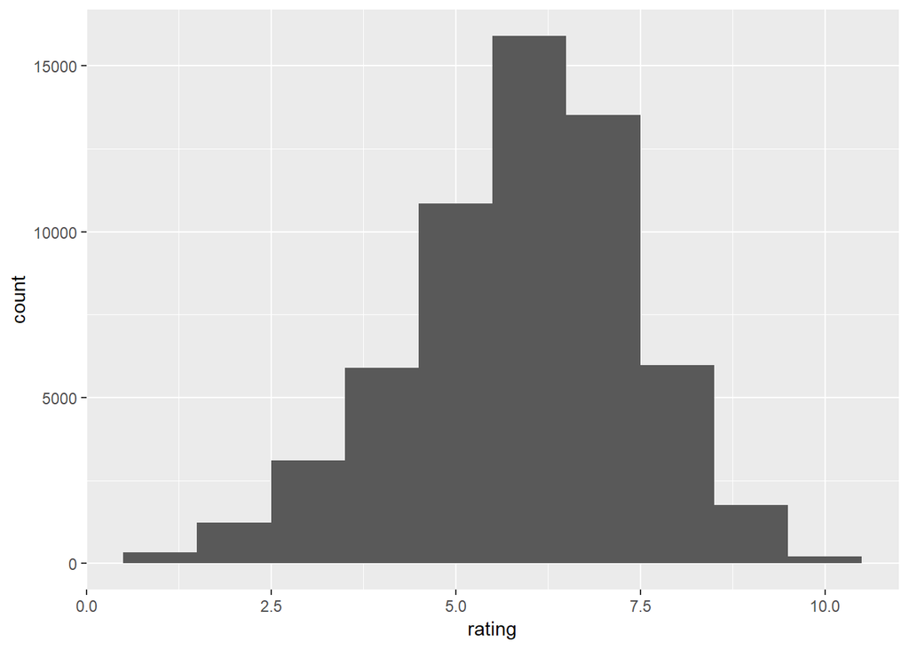

```r
# birwidth: histogram의 막대의 넓이 조절
p <- p + geom_histogram(binwidth = 1) ; p
```

- histogram에 확률밀도곡선 표현

```r
head(movies)
```

```
## # A tibble: 6 x 24
##   title  year length budget rating votes    r1    r2    r3    r4    r5
##   <chr> <int>  <int>  <int>  <dbl> <int> <dbl> <dbl> <dbl> <dbl> <dbl>
## 1 $      1971    121     NA    6.4   348   4.5   4.5   4.5   4.5  14.5
## 2 $100~  1939     71     NA    6      20   0    14.5   4.5  24.5  14.5
## 3 $21 ~  1941      7     NA    8.2     5   0     0     0     0     0
## 4 $40,~  1996     70     NA    8.2     6  14.5   0     0     0     0
## 5 $50,~  1975     71     NA    3.4    17  24.5   4.5   0    14.5  14.5
## 6 $pent  2000     91     NA    4.3    45   4.5   4.5   4.5  14.5  14.5
## # ... with 13 more variables: r6 <dbl>, r7 <dbl>, r8 <dbl>, r9 <dbl>,
## #   r10 <dbl>, mpaa <chr>, Action <int>, Animation <int>, Comedy <int>,
## #   Drama <int>, Documentary <int>, Romance <int>, Short <int>
```

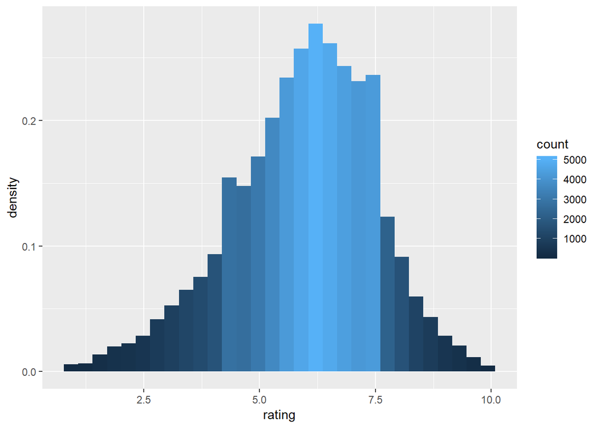

```r
p <- ggplot(movies, aes(rating))
p <- p + geom_histogram(aes(y=..density..,fill = ..count..)) ; p
```

```r
# 히스토그램 그리기
```

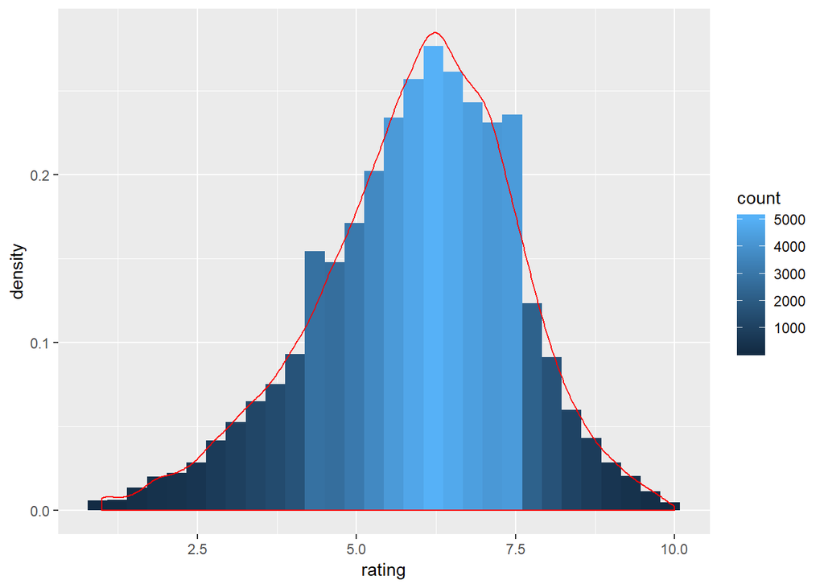

```r
p <- p + geom_density(colour= "red") ; p #확률밀도곡선 그리기
```

```r
p <- p + scale_fill_gradient(low="white",high = "#496ff5") ; p
```

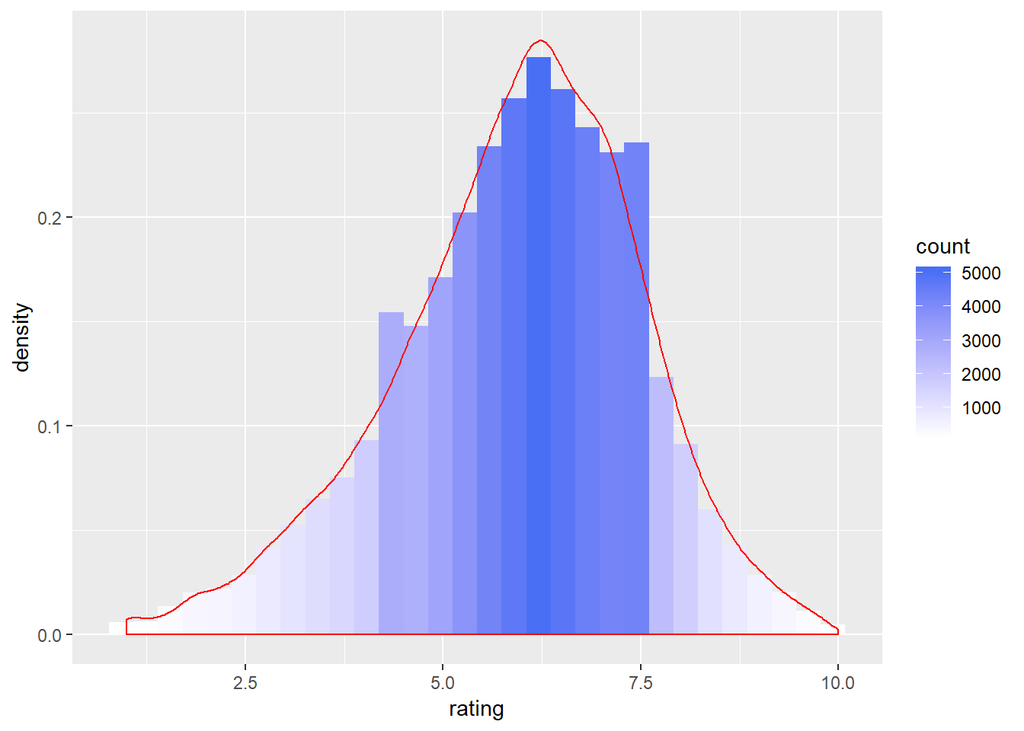

```r
#그라데이션 추가
```

# 2-2-5. 확률밀도곡선

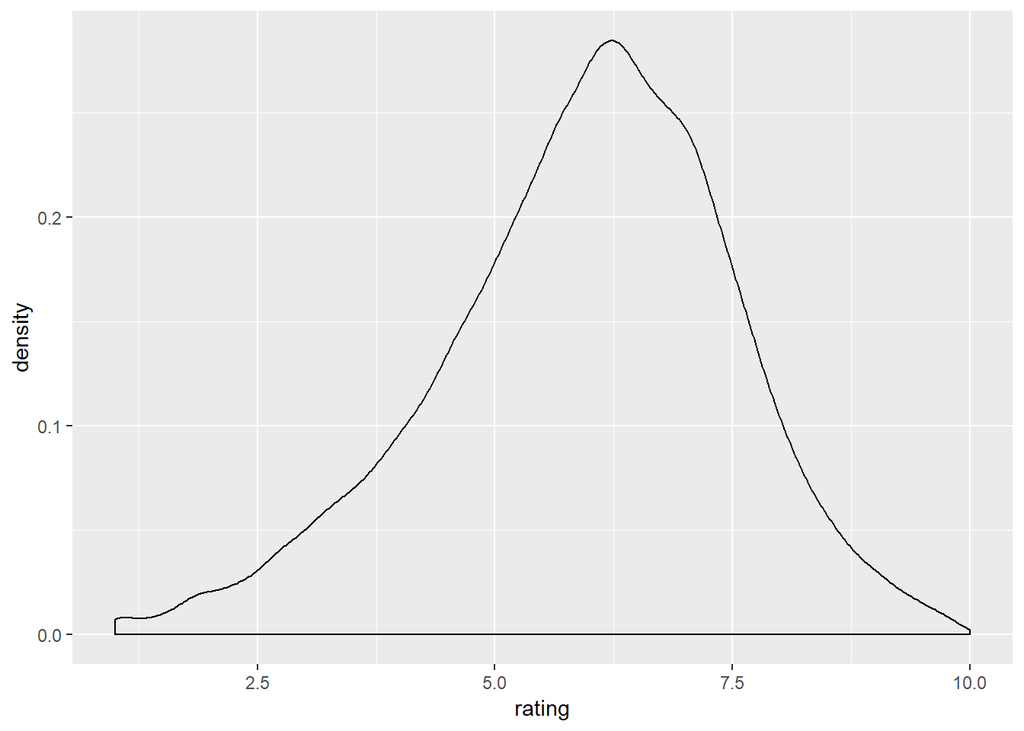

```r
p <- ggplot(movies, aes(rating))
p <- p + geom_density() ; p
```

- 여러개의 확률밀도곡선 그리기
- aes(fill=factor(mpaa))인수로 mpaa분류한 rating의 확률밀도곡선 그리기

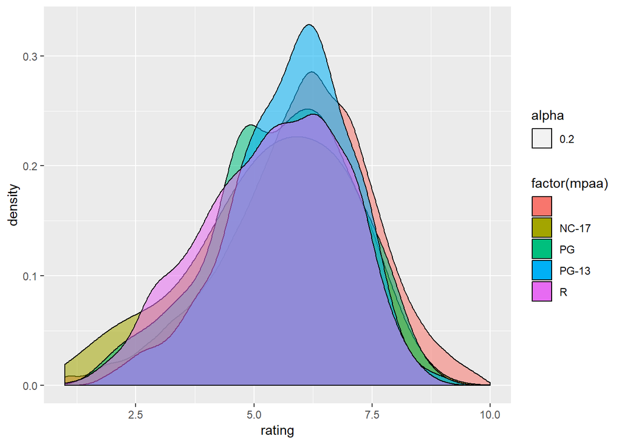

```r
p <- ggplot(movies, aes(rating))
p <- p + geom_density(aes(fill=factor(mpaa), alpha=.2)) ; p
```

# 3. leaflet

- leaflet패키지는 interactive한 그래프를 그릴 수 있는 패키지
- 구글맵과 오픈스트리트 맵을 이용하여 공간 데이터를 시각화함

```r
#install.packages("leaflet")
#install.packages("dplyr")
library(leaflet)
library(dplyr)
m <- leaflet() %>% addTiles()
m <- m %>% setView(127.0462, 37.2830, zoom = 15) #아주대 경도위 위도 설정
m %>% addPopups(127.0462, 37.2830, 'Here is Ajou University!')
```

[interactive chart not shown]

```r
m
```

[interactive chart not shown]

# 3-3. leaflet예제

- addTiles()함수와 addAwesomeMarkers함수 사용
- 서울시 교통 돌발상황 조회 서비스 데이터 중 일부를 사용하여 지도에 표시하기

데이터로드 및 시각화

```r
setwd("C:/Users/hyere/Desktop/R/PR")
traffic <- read.csv("traffic.csv", fileEncoding = "utf-8")
range(traffic$start.pos.x)
```

```
## [1]   0.0000 129.1827
```

```r
range(traffic$start.pos.y)
```

```
## [1]  0.00000 37.69728
```

```r
traffic1 <- traffic[traffic$start.pos.x!=0 & traffic$start.pos.y !=0,]

leaflet(traffic1) %>% addTiles() %>% addAwesomeMarkers(~start.pos.x, ~start.pos.y)
```

[interactive chart not shown]

# 출처

- 1. R을 활용한 데이터 시각화 - 유충현, 홍석학
- 2. ggplot - 김성근
- 3. R라뷰 - 서진수

# 연습문제

## 문제1

```r
getwd()
```

```
## [1] "C:/Users/hyere/Desktop/R/PR"
```

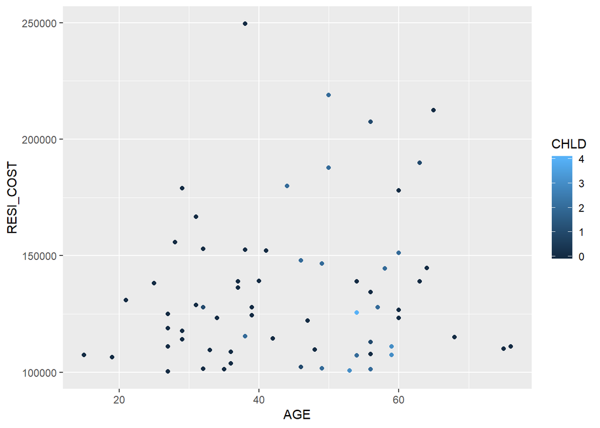

```r
setwd("C:/Users/hyere/Desktop/R/PR")
B_C <- read.csv("Bgcon_Cust_DATA.csv")  #파일 불러오기 #파일이 안열려 fileEncoding = "utf-8" 부분을 삭제했습니다ㅠㅠ

B_C_1 <- B_C[B_C$RESI_COST>=100000,] #RESI_COST>=100000 부분 추출

library(ggplot2)
h <- ggplot(B_C_1, aes(AGE, RESI_COST)) + geom_point(aes(colour=CHLD)) ; h  #문제에 맞는 그래프 그리기
```

# 문제2

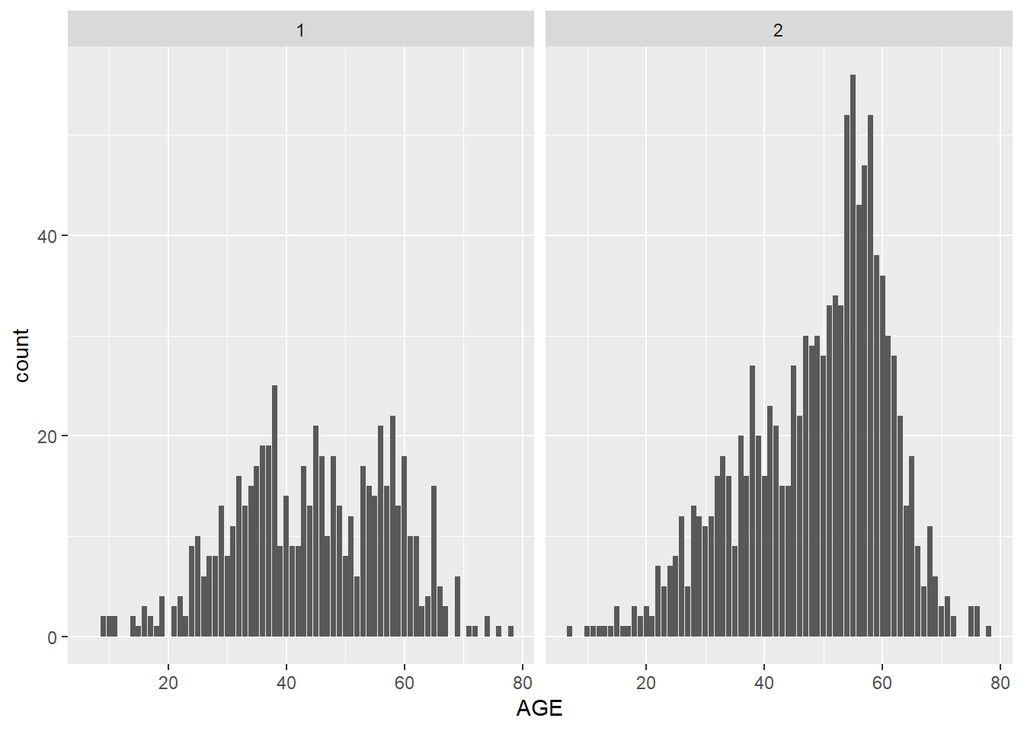

```r
B_C_2 <- B_C[B_C$SIU == "Y",]  #보험사기고객 추출

library(ggplot2)
ggplot(B_C_2, aes(x = AGE)) + geom_bar() + facet_grid(~GENDER)
```

```r
# 문제에 맞는 그래프 그리기
```

# 문제3

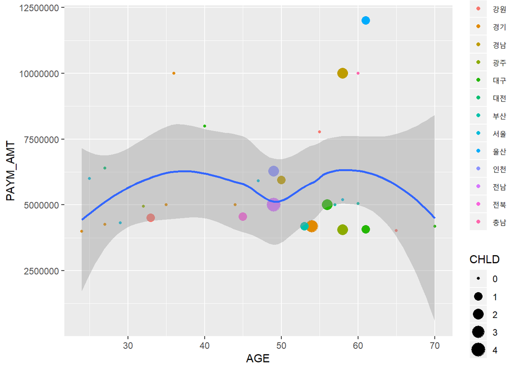

```r
B_C3 <- B_C_2[B_C_2$PAYM_AMT>= 4000000 & B_C_2$PAYM_AMT<= 14000000,] #보험 사기고객중 지불금액이 4000000이상, 14000000이하인 고객 추출

ggplot(B_C3, aes(AGE, PAYM_AMT)) + geom_point(aes(colour=CTPR, size=CHLD)) + geom_smooth(method = 'loess')  #문제에 맞는 그래프 그리기
```

# 문제4

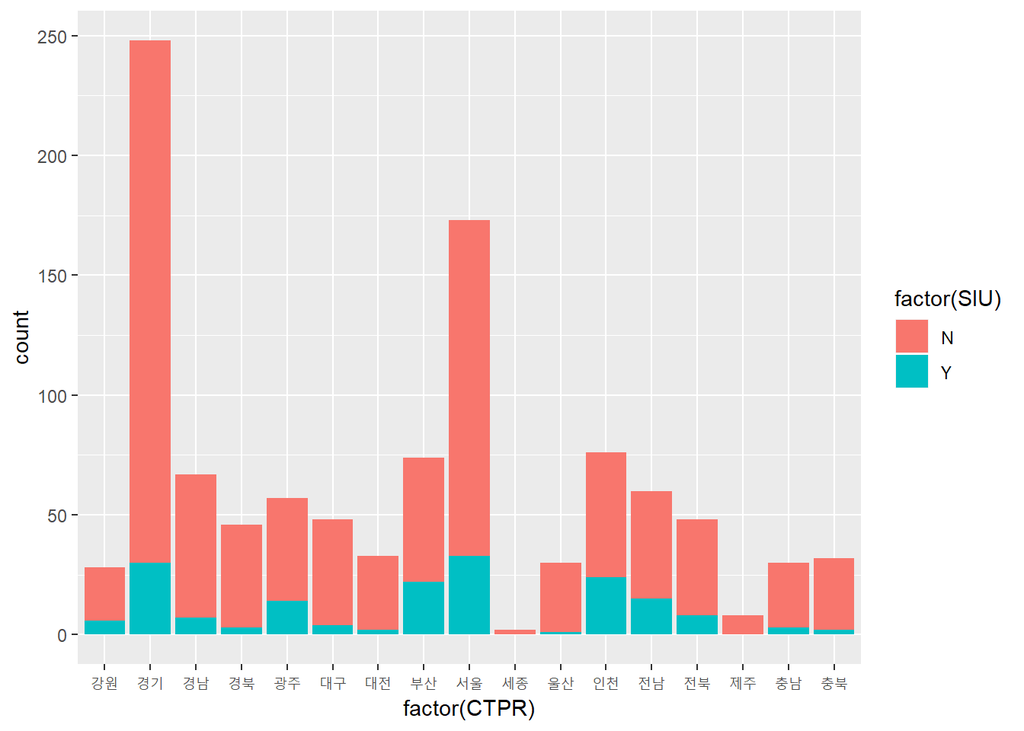

```r
B_C4 <- B_C[B_C$FP_CA == "Y",]  #당사 FP로서의 경력이 있는 고객 추출

ggplot(B_C4, aes(factor(CTPR))) + geom_bar(aes(fill=factor(SIU)))
```

```r
#문제에 맞는 그래프그리기
```

# 문제5

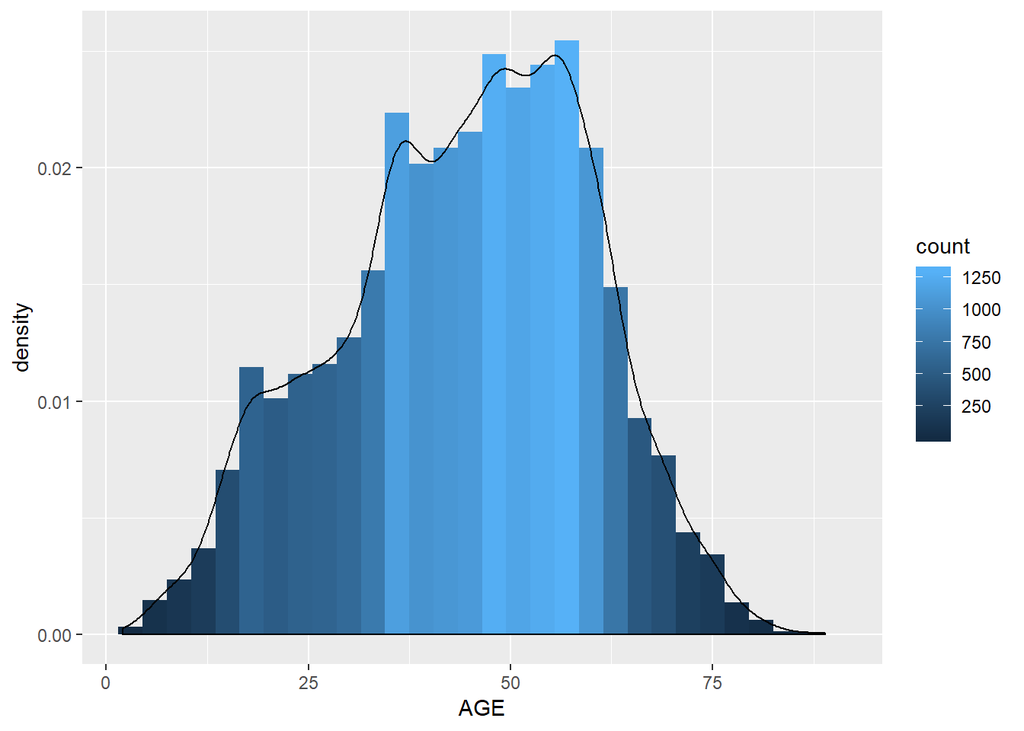

```r
B_C5 <- B_C[B_C$SIU == "N",]  #보험사기고객이 아닌 고객(일반고객) 추출

ggplot(B_C5, aes(AGE)) + geom_histogram(aes(y=..density..,fill = ..count..)) + geom_density(colour= "black")  #문제에 맞는 그래프 그리기
```